# AFDMD-111 Estadística

Subindexado de datos y gráficas

Cristhian Jhovany Gutierrez Jimenez

11/09/2023

# Subindexado de vectores atómicos

El subindexado de vectores atómicos permite obtener partes de un vector atómico (los primeros elementos, los 10 últimos, etc.) y es útil en muchos tipos de análisis que suceden en diversas ramas de la ciencia. Supongamos que tenemos lo siguiente:

```r
dnormales <- rnorm(20)    # 10 numeros aleatorios de una dist. normal
dnormales   # Imprimimos el vector
```

```
 [1]  1.99540249 -0.69089961  0.50953054 -2.61960036  0.96143224  0.63097402
 [7]  0.03286031 -1.66647976 -0.92136062 -0.68222882  1.17153970  1.00551043
[13]  1.35432891  0.28424170  0.45410442 -0.22450736 -0.08971183  2.33255905
[19]  0.22752762  0.67934902
```

## Ejercicios:

1.- ?Cuál es el resultado de `dnormales[order(x)]`, `dnormales[1:length(vec)]`, `dnormales[-20]`, `dnormales[vec>0.5]`?  
nos arrojara numeros aleatorios

2.- ?Qué sucede si hacemos `dnormales[0:3]`? sucede que se selecionan los elementos desdel 0 al 3 ?Cuál es la longitud del vector? sucede que se selecionan los elementos desdel 0 al 3

3.- Ahora suponga que `x <- c(1,24,8)` y `uno <- c(T,T,F)`. ?Qué sucede si hacemos `x[uno]`? arrojara un nuevo vector con los elementos de x dependiendo de si es verdadero ?Y si hacemos `x[as.double(uno)]`?  
arrojara el mismo resultado que el anterior osea c(1,24)

#### Nota

> Puede referirse a las [diapositivas](https://monoxide2000.github.io/slidesUQroo2)

# Subindexado de listas

Las listas se pueden subindexar mediante los operadores `[`, `[[` y `$`. Recordemos que cuando indexamos con `[`, el resultado siempre es del mismo tipo. Ahora suponga que tenemos la siguiente lista:

```r
listaPrueba <- list(Mayusculas = LETTERS[1:15], Ciudades = c("Cancun", "Playa", "Chetumal", "Merida"), casos = list(a=23, b= 1:8, c=list(d=1,e=TRUE)))
str(listaPrueba)
```

```
List of 3
 $ Mayusculas: chr [1:15] "A" "B" "C" "D" ...
 $ Ciudades  : chr [1:4] "Cancun" "Playa" "Chetumal" "Merida"
 $ casos     :List of 3
  ..$ a: num 23
  ..$ b: int [1:8] 1 2 3 4 5 6 7 8
  ..$ c:List of 2
  .. ..$ d: num 1
  .. ..$ e: logi TRUE
```

Ejercicios (en base al objeto `listaPrueba`)

1.- ?Con qué comando puedo obtener la lista casos? listaPrueba[[“casos”]]

2.- ?Cómo puedo obtener el único valor lógico de `listaPrueba`? listaPrueba$casos$e

3.- ?Qué sucede si hago `listaPrueba[[3]]$c[[2]]`, es esto equivalente a `listaPrueba$casos[[3]][[2]]`? Explique la expresión listaPrueba[[3]]$c[[2]]accede al segundo elemento de la lista llamada "c" que está dentro del tercer elemento de la lista listaPrueba. Mientras que listaPrueba$casos[[3]][[2]]hace lo mismo, accediendo al segundo elemento de la lista llamado “casos” que está dentro del tercer elemento de la lista listaPrueba.

4.- ?Cuál es la diferencia entre `listaPrueba[1]` y `listaPrueba[[1]]`? listaPrueba[1] devuelve una lista que contiene el primer elemento, mientras que listaPrueba[[1]] devuelve el primer elemento directamente sin estar contenido en una lista adicional.

5.- ?Cómo puedo obtener el objeto `"Chetumal"`? con el comando listaPrueba$Ciudades[3]

6.- ?Cómo puedo obtener el tercer elemento de `b`? con el comando listaPrueba$casos$b[3]

# Indexado de matrices

Suponga que tenemos la matriz:

```r
matriz1 <- matrix(rnorm(20), nrow=5)
dim(matriz1)
```

```
[1] 5 4
```

## Ejercicios:

A partir de `matriz1`, hallar:

1.- La matriz que consta de las primeras dos columnas de `matriz1`. matrix(rnorm(20), nrow=5) matriz1[, 1:2]

2.- La matriz que consta de las primeras dos filas y dos columnas de `matriz1`. matrix(rnorm(20), nrow=5) matriz1[1:2, 1:2]

3.- La matriz que consta del elemento $a_{2,3}$ de `matriz1` matrix(rnorm(20), nrow = 5) matriz1[2, 3]

4.- ?Son equivalentes los comandos `matriz1[c(1,2),c(3,4)]` y `matriz1[1:2,c(3,4)]`? (tip: puede probar con el comando `identical`) si con equivalentes identical(submatriz1, submatriz2)

# Subindexado de `data.frame`

El subindexado de `data.frames` es similar al subindexado por medio de listas y matrices. En este caso nos concentraremos en el paquete `dplyr` que permite manipular `data.frames`. Cualquier paquete en `R` se puede instalar mediante el comando `install.packages(<nombre.paquete>)`, por ejemplo para instalar `dplyr` hacemos:

```r
install.packages("dplyr", dependencies = TRUE)   # instalo el paquete
library(dplyr)         # Cargo el paquete para trabajar con sus funciones
```

## Tarea:

1.- Investigar para qué sirve el paquete `dplyr`. El paquete dplyren R es una herramienta popular para realizar manipulaciones y transformaciones de datos de manera eficiente. Fue desarrollado por Hadley Wickham y es parte del conjunto de paquetes conocidos como el “tidyverse”. dplyrproporciona una gramática de manipulación de datos consistente y fácil de entender. La gramática consistente de dplyrfacilitar la escritura de código legible y permite realizar análisis de datos de manera más eficiente.

2.- ?Cuáles son los comandos importantes del paquete `dplyr`? -filter(): Filtra filas según condiciones específicas. -select(): Selecciona columnas específicas del conjunto de datos. -arrange(): Ordena filas del conjunto de datos. -mutate(): Agrega nuevas columnas o modifica existentes. -summarise(): Agrega resúmenes estadísticos a los datos. -group_by(): Agrupa el conjunto de datos por una o más columnas. -distinct(): Selecciona solo las filas únicas del conjunto de datos. -rename(): Cambia el nombre de las columnas. -summarize(): Versión alternativa de summarise(), también puede usarse. -join(): Combina dos conjuntos de datos por medio de una operación de unión.

3.- Supongamos que tenemos un `data.frame` `df <- data.frame(a=1:8, letras =letter[1:8])`, qué sucede si aplico `select(df, a)`. se seleccionara únicamente la columna “a”, manteniendo solo esa columna en el resultado. ?Y si aplico `filter(df, a<5)`? se filtarria las filas del data frame donde el valor en la columna “a” sea menor que 5

# Gráficos de funciones bidimensionales

Los gráficos permiten mostrar múltiples características de una función. Los máximos, mínimos, etc., son métricas que nos dicen mucho acerca del comportamiento de una función. `R` nos permite graficar funciones de manera sencilla utilizando el concepto de vector. Por ejemplo, quizás estemos interesados en conocer la forma de onda de la función seno acotada, la cual se define matemáticamente mediante la siguiente fórmula:

$$f(t) = \begin{cases}
\sin(2 \pi t) & \mbox{para} -1 < t < 1\\
0 & \mbox{resto}.
\end{cases}$$
Y la cual en `R` se graficar? de la siguiente manera:

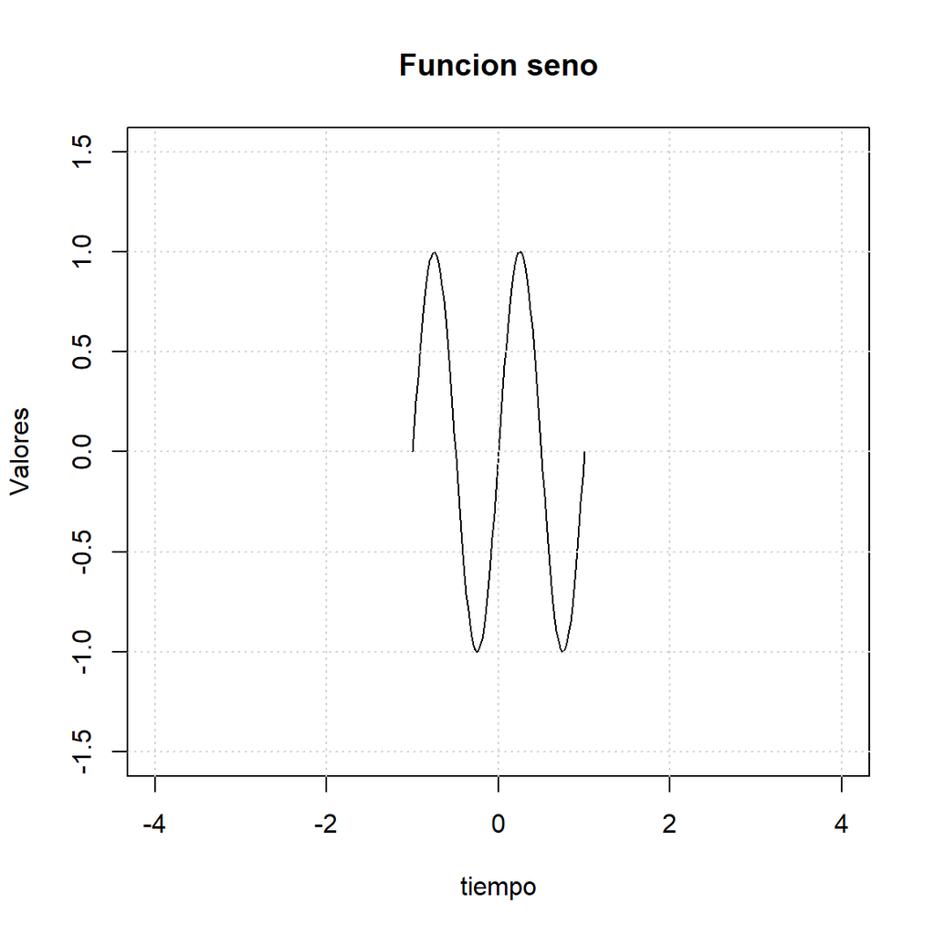

```r
t  <- seq(-1, 1, length=100)
ft   <- sin(2*pi*t)           # Se calcula la funcion seno a partir de t
plot(t, ft, type="l", xlim=c(-4,4), ylim=c(-1.5,1.5), main="Funcion seno", xlab="tiempo", ylab="Valores")
grid()
```

`R` permite añadir gráficos o puntos mediante las funciones `lines()` y `points()`. El siguiente código ejemplifica lo anterior.

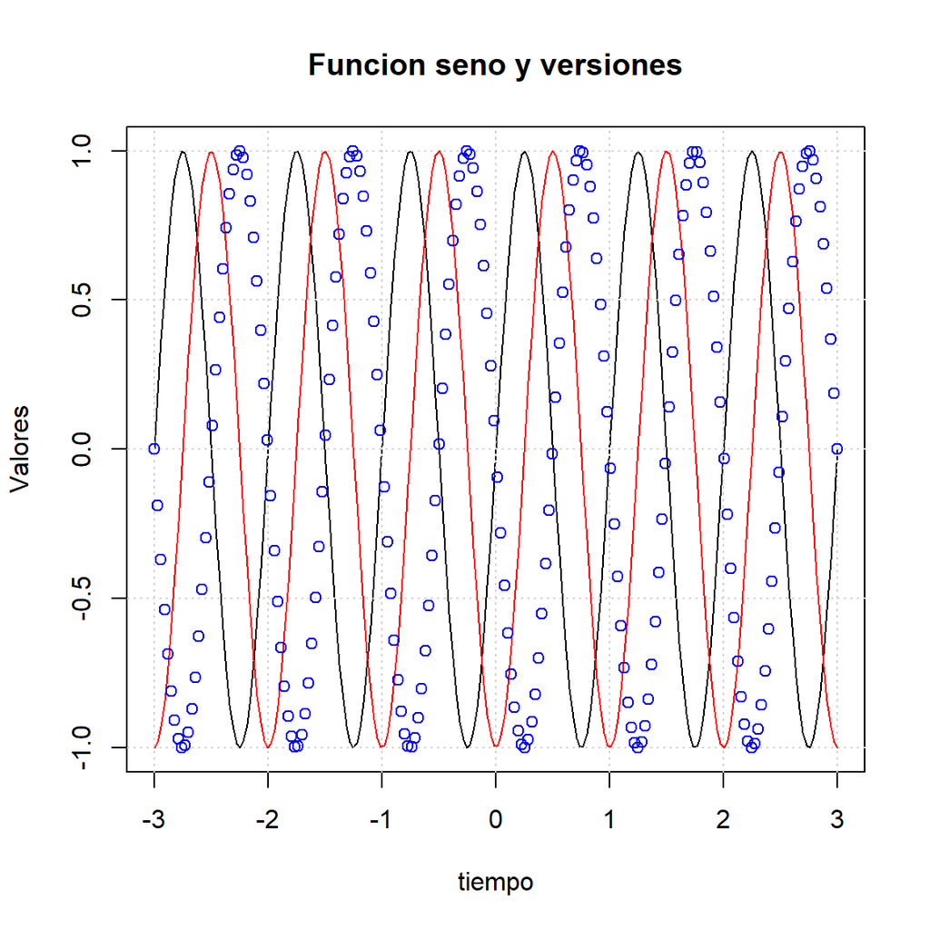

```r
t  <- seq(-3,3, length=200)
f1 <- sin(2*pi*(t))
f2 <- sin(2*pi*(t-1/4))
f3 <- sin(2*pi*(t-1/2))
plot(t,f1, type= "l", main="Funcion seno y versiones", xlab="tiempo", ylab="Valores")
grid()
lines(t,f2, col="red")
points(t,f3,col="blue")
```

De igual manera se pueden definir funciones por tramos con el comando `ifelse()`, por ejemplo grafiquemos la siguiente función:

$$f(t) = \begin{cases}
2+t & \; -2<t<-1\\
1 & \; -1<t<1\\
2-t & \;1<t<2\\
0 & \; \mbox{resto}
\end{cases}$$

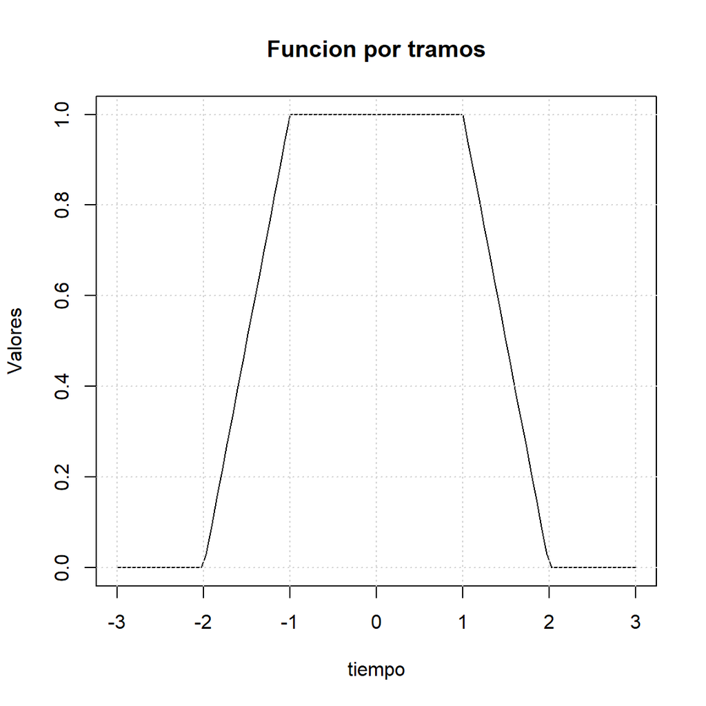

```r
t <- seq(-3,3, length=100)
ft <- ifelse(t> -2 & t < -1, 2+t, ifelse(t>= -1 & t <= 1, 1, ifelse(t>1 & t< 2, 2-t, 0)))
plot(t, ft, type = "l", main="Funcion por tramos", xlab="tiempo", ylab="Valores")
grid()
```

### Ejercicios:

Graficar las siguientes funciones:

$$f(t) = \begin{cases}
1 & \; t>0\\
0 & \; \mbox{resto}
\end{cases}$$

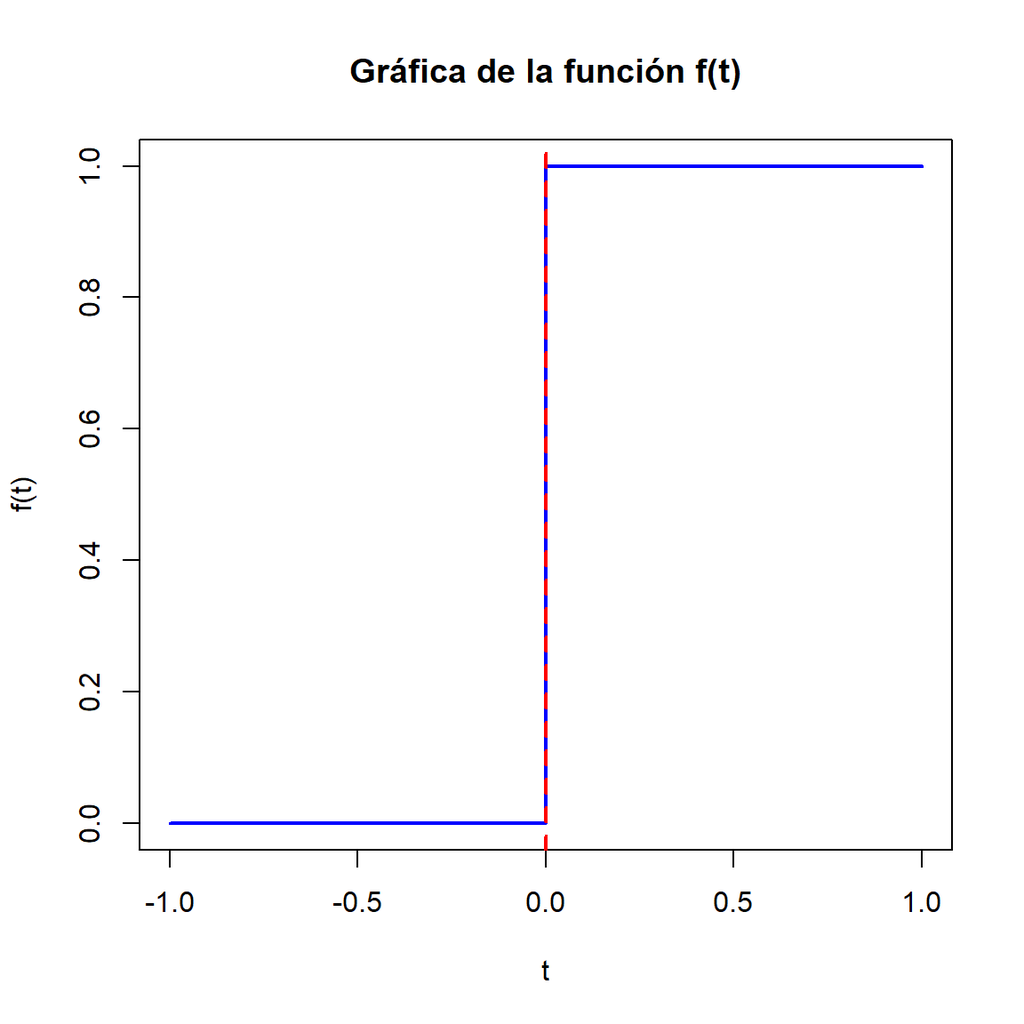

```r
t <- seq(-1, 1, length.out = 1000)
y <- ifelse(t > 0, 1, 0)
plot(t, y, type = 'l', col = 'blue', lwd = 2, xlab = 't', ylab = 'f(t)', main = 'Gráfica de la función f(t)')
abline(v = 0, col = 'red', lwd = 2, lty = 2)
```

$$f(t) = \begin{cases}
1+t & \; -1<t<0\\
1-t & \; 0 \le t<1\\
0 & \; \mbox{resto}
\end{cases}$$

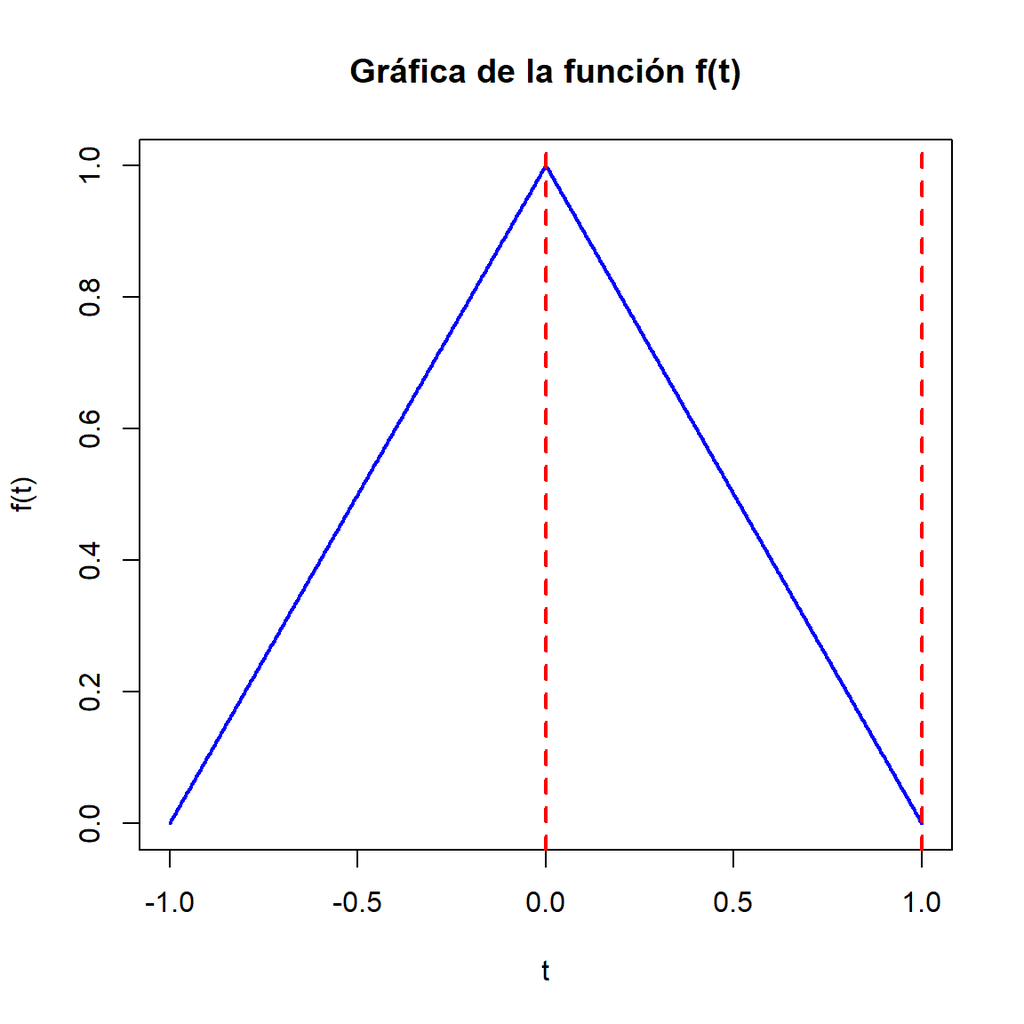

```r
t <- seq(-1, 1, length.out = 1000)
y <- ifelse(t > -1 & t < 0, 1 + t, ifelse(t >= 0 & t < 1, 1 - t, 0))
plot(t, y, type = 'l', col = 'blue', lwd = 2, xlab = 't', ylab = 'f(t)', main = 'Gráfica de la función f(t)')
abline(v = c(0, 1), col = 'red', lwd = 2, lty = 2)
```

$$f(t) = \begin{cases}
\mbox{e}^{-2t} & \; 0<t<2\\
1+t & \; -1<t<0\\
0 & \; \mbox{resto}
\end{cases}$$

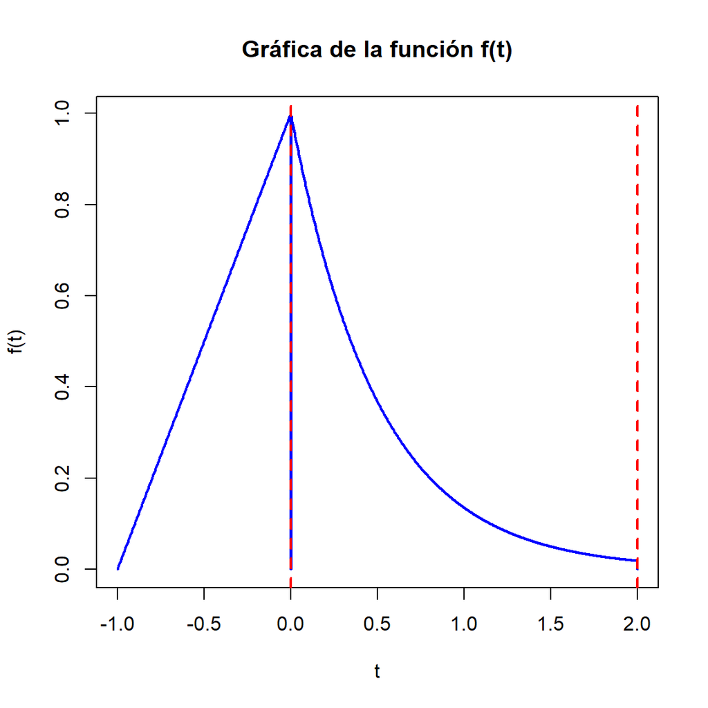

```r
t <- seq(-1, 2, length.out = 1000)
y <- ifelse(t > 0 & t < 2, exp(-2*t), ifelse(t > -1 & t < 0, 1 + t, 0))
plot(t, y, type = 'l', col = 'blue', lwd = 2, xlab = 't', ylab = 'f(t)', main = 'Gráfica de la función f(t)')
abline(v = c(0, 2), col = 'red', lwd = 2, lty = 2)
```

# Gráficos 3D

Los gráficos en 3D permiten visualizar funciones del tipo: $f(x,y)$, donde $x$ e $y$ representan variables independientes. Como ejemplo veamos la forma en la cual `R` grafica la siguiente funci?n $f(x,y) = \sqrt{16-4x^2-y^2}$:

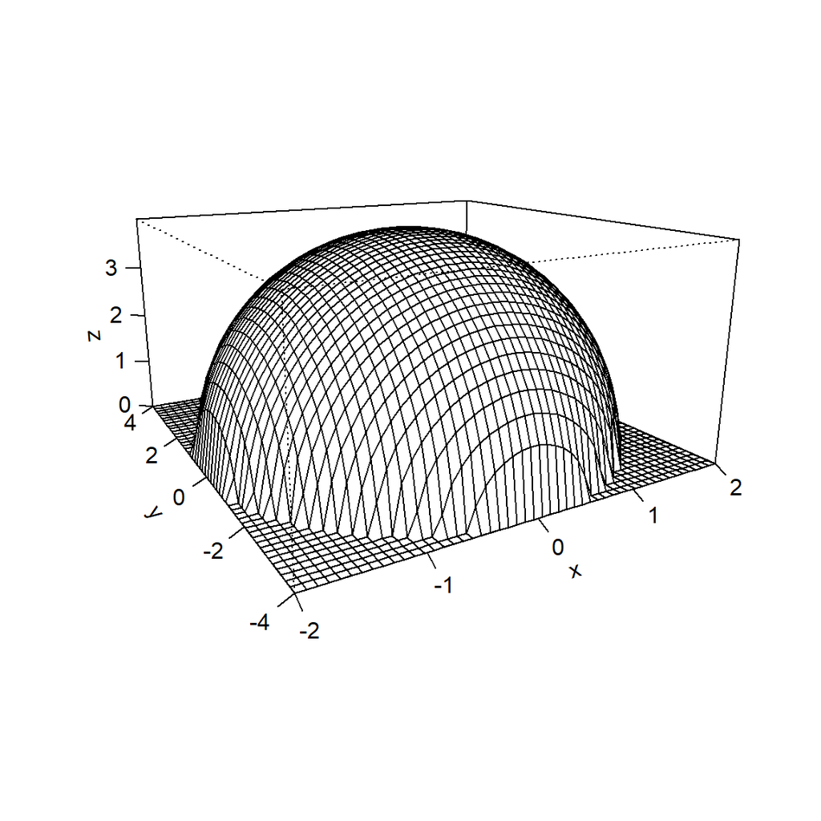

```r
x <- seq(-2,2,length=50)
y <- seq(-4,4, length=50)
z <- outer(x,y,function(x,y) sqrt(16-4*x^2-y^2))
z[is.na(z)] <- 0
persp(x,y,z, theta=-30, expand=0.5,ticktype = "detailed")
```

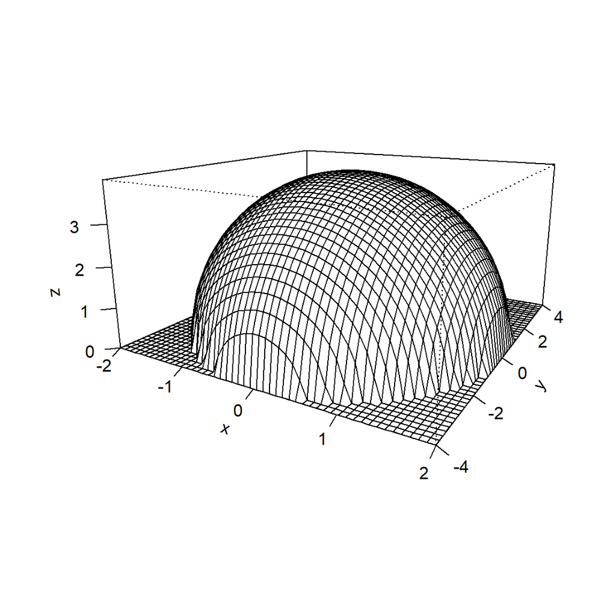

```r
persp(x,y,z, theta=30, expand=0.5, ticktype = "detailed")
```

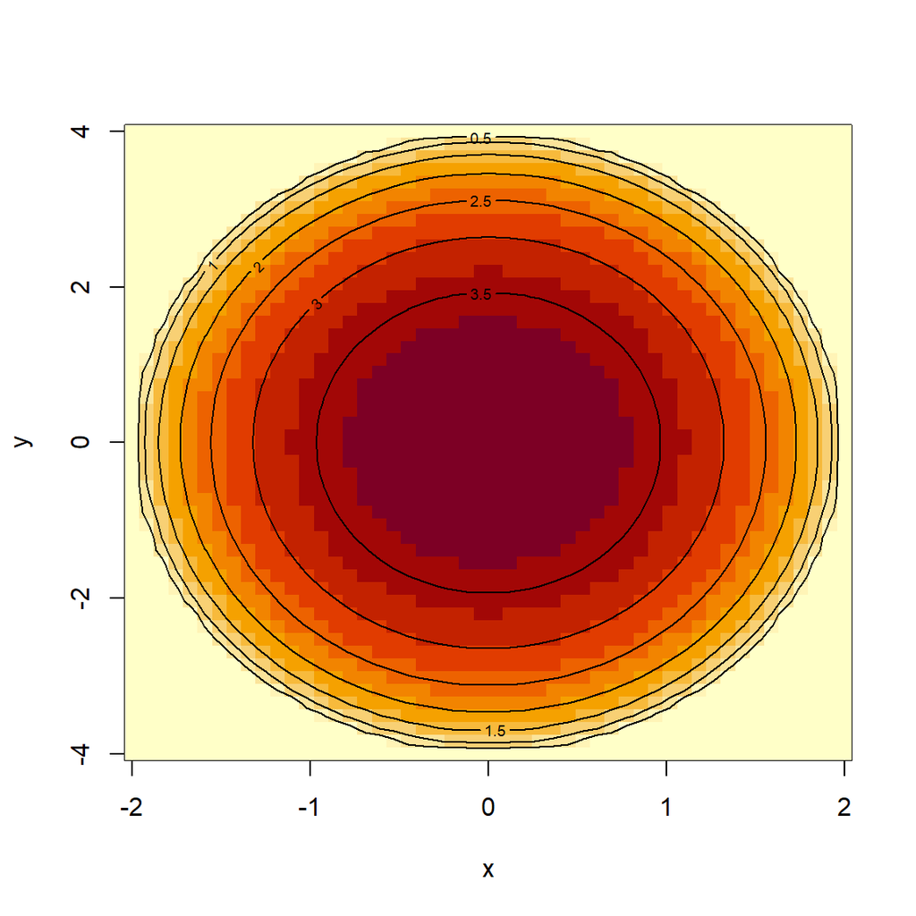

```r
image(x,y,z)
contour(x,y,z, add=TRUE)
```

Ejemplos: Ahora veamos la manera de hacerla con más funciones.

#### Ahora para la función $z = y^2-x^2$

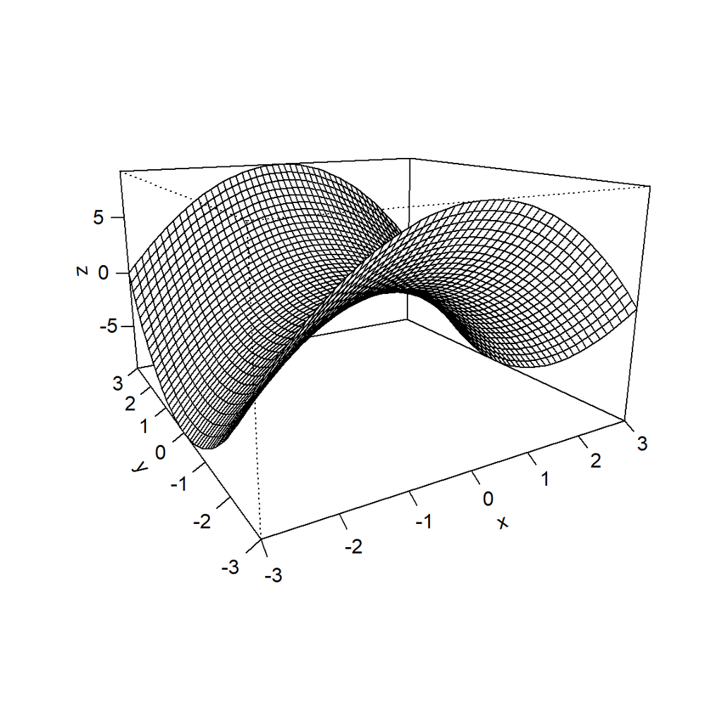

```r
x <- seq(-3,3,length=50)
y <- seq(-3,3, length=50)
z <- outer(x,y,function(x,y) y^2-x^2)
persp(x,y,z, theta=-30, expand=0.6, ticktype = "detailed")
```

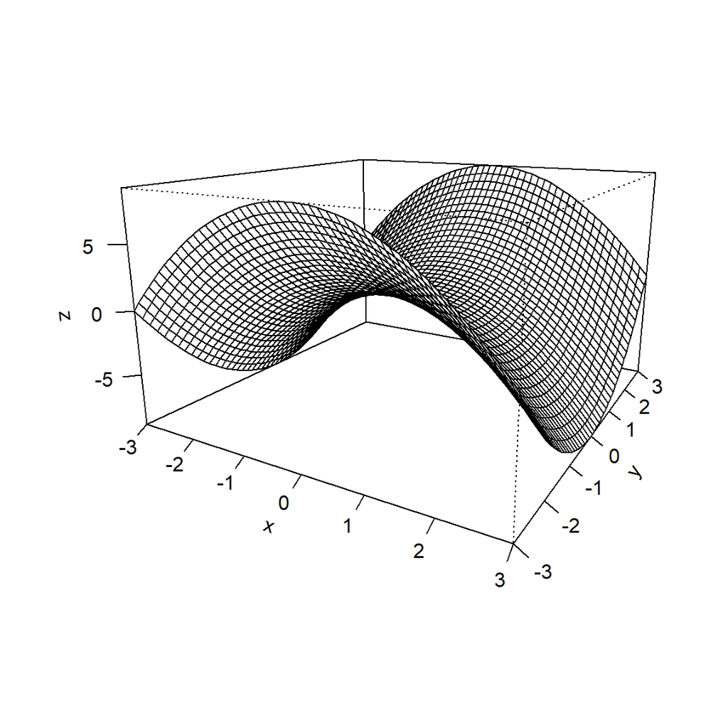

```r
persp(x,y,z, theta=30, expand=0.6, ticktype = "detailed")
```

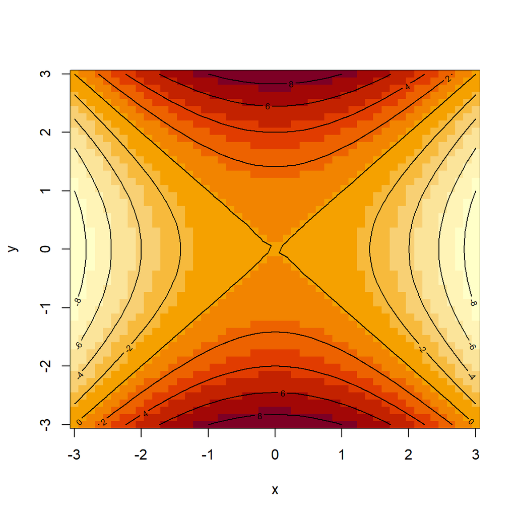

```r
image(x,y,z)
contour(x,y,z, add=TRUE)
```

#### Ahora para la función $f(x,y)= (2+x^2-y^2) \mbox{e}^{1-x^2-(y^2)/4}$

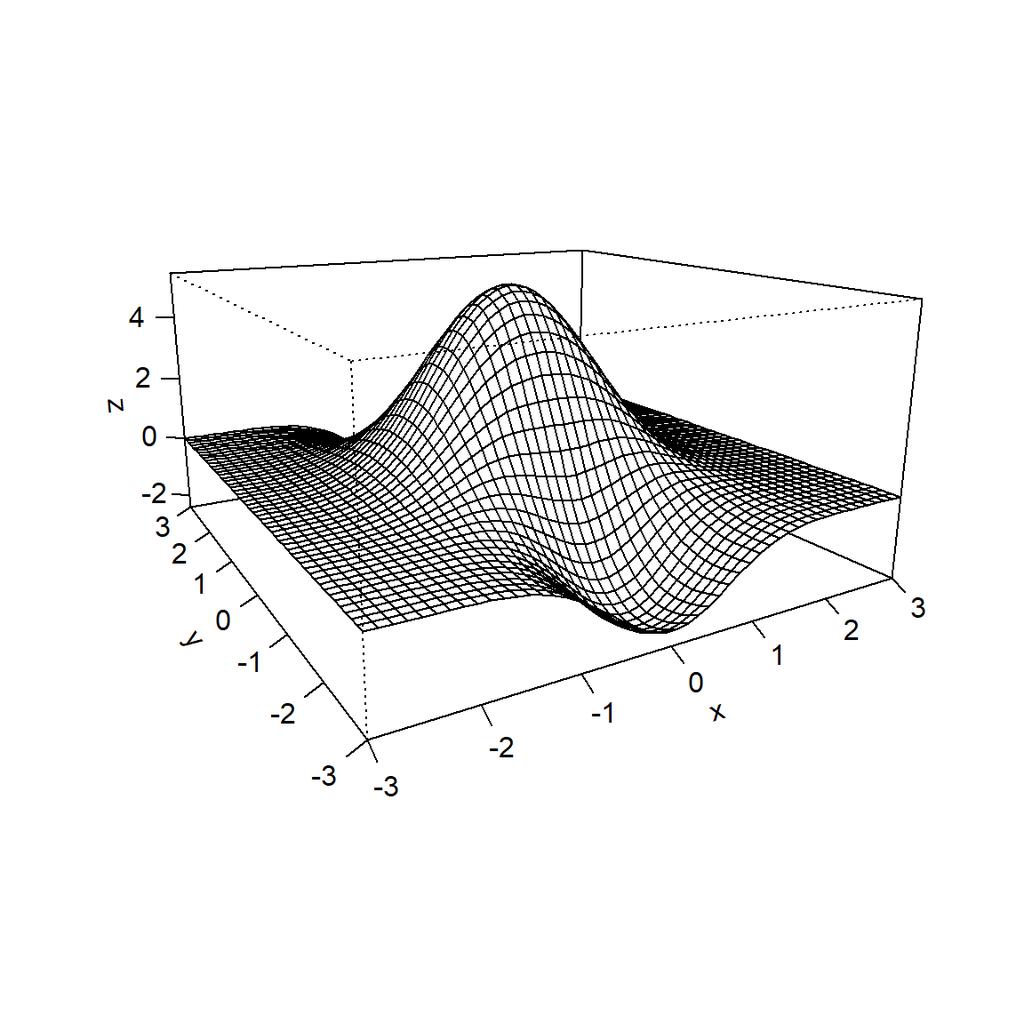

```r
x <- seq(-3,3,length=50)
y <- seq(-3,3, length=50)
z <- outer(x,y,function(x,y) (2-y^2+x^2)*exp(1-x^2-(y^2)/4))
persp(x,y,z, theta=-30, expand=0.5, ticktype = "detailed")
```

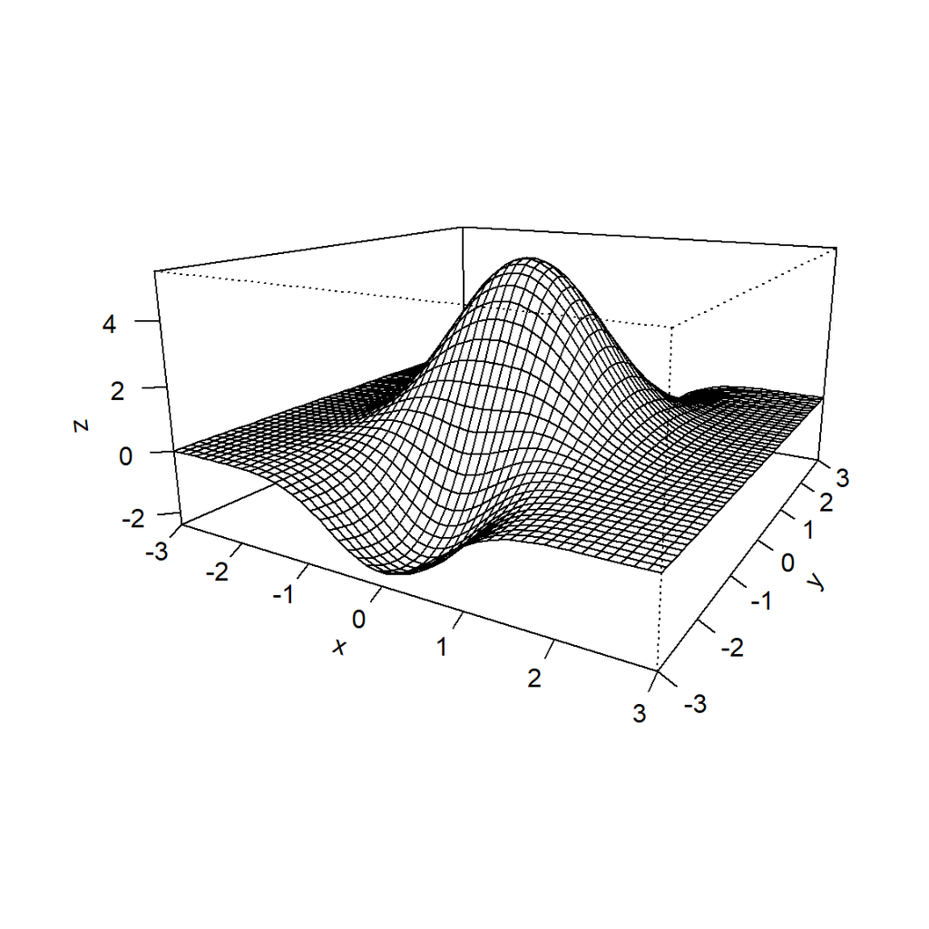

```r
persp(x,y,z, theta=30,expand=0.5,ticktype = "detailed")
```

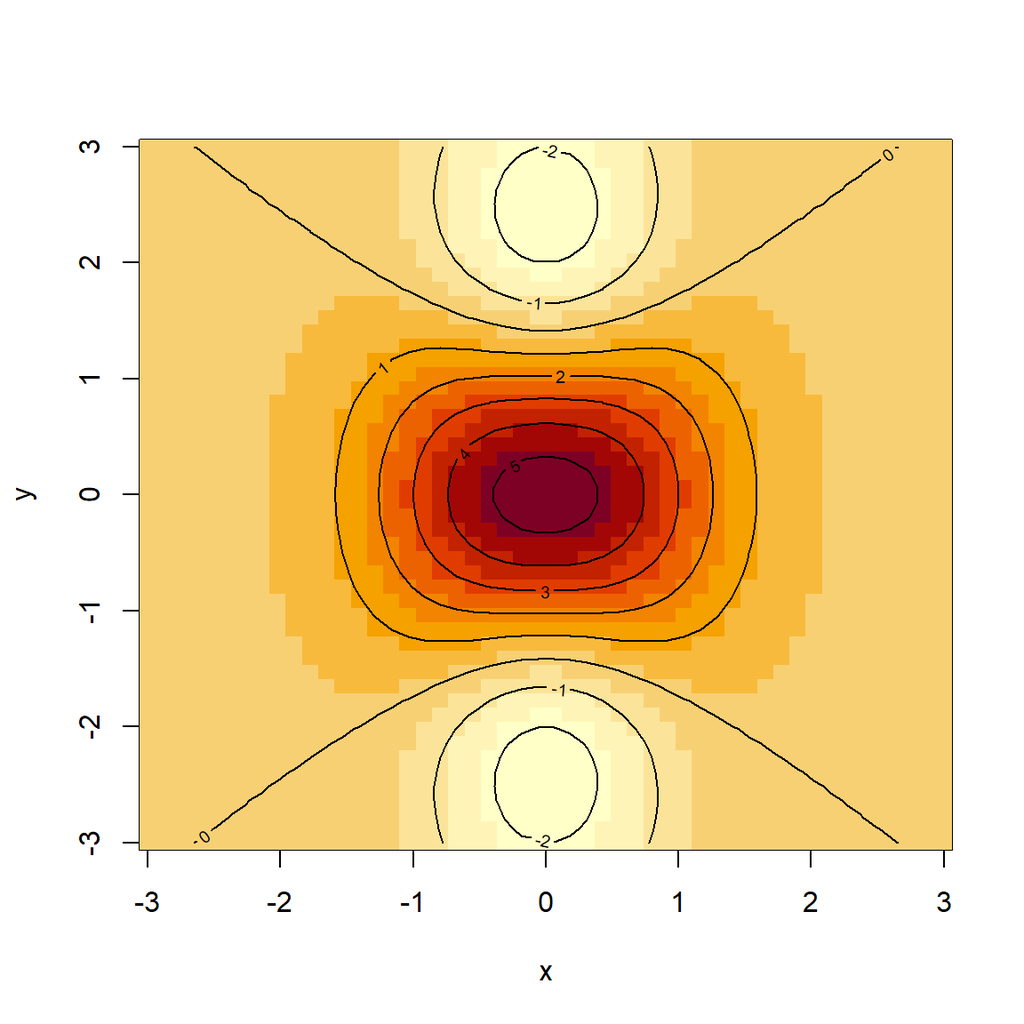

```r
image(x,y,z)
contour(x,y,z, add=TRUE)
```

#### Ejercicios:

[figure not shown]

1.- z= x+y, c= -1,0,2,4

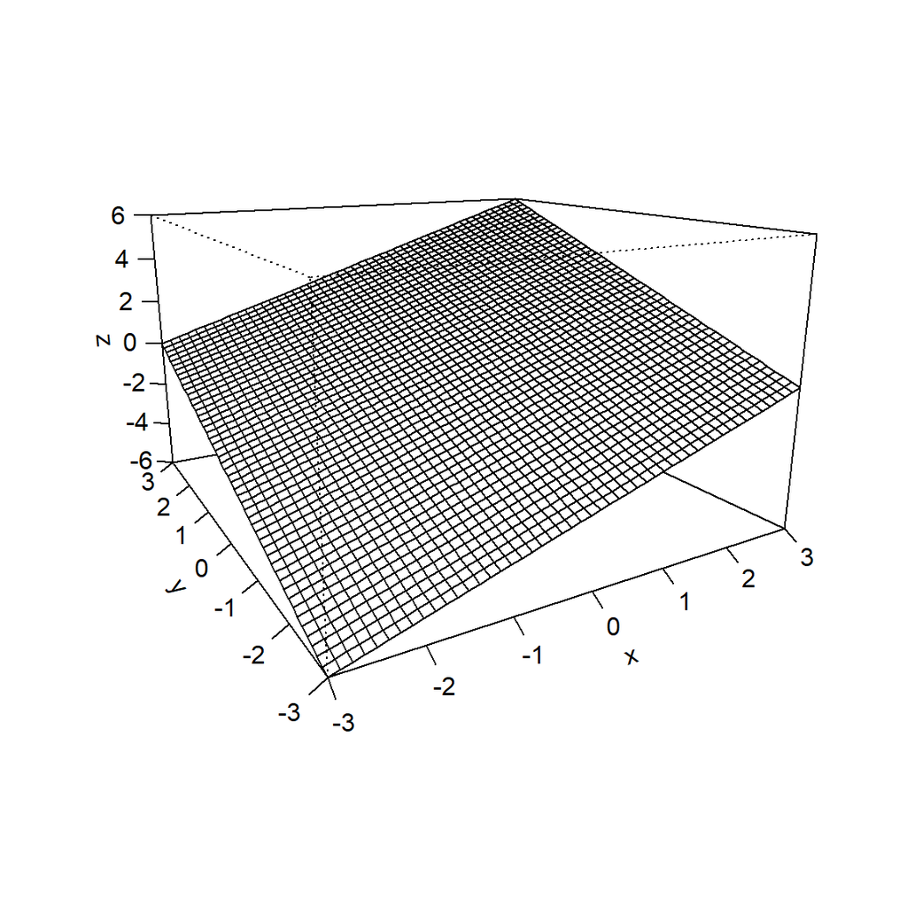

```r
x <- seq(-3,3,length=50)
y <- seq(-3,3, length=50)
z <- outer(x,y,function(x,y) y+x)
persp(x,y,z, theta=-30, expand=0.6, ticktype = "detailed")
```

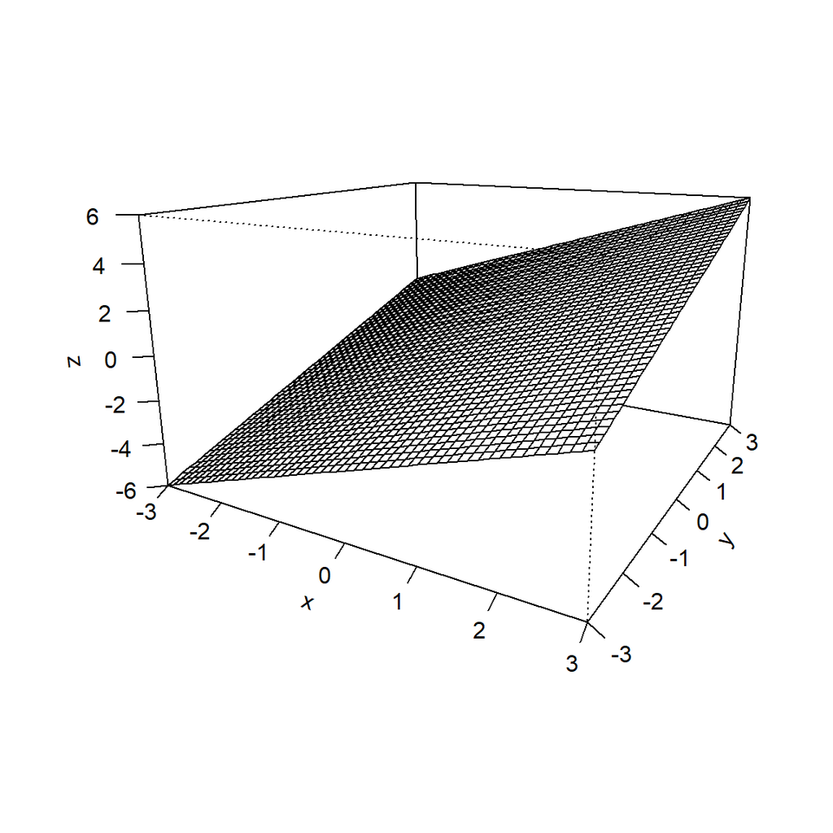

```r
persp(x,y,z, theta=30, expand=0.6, ticktype = "detailed")
```

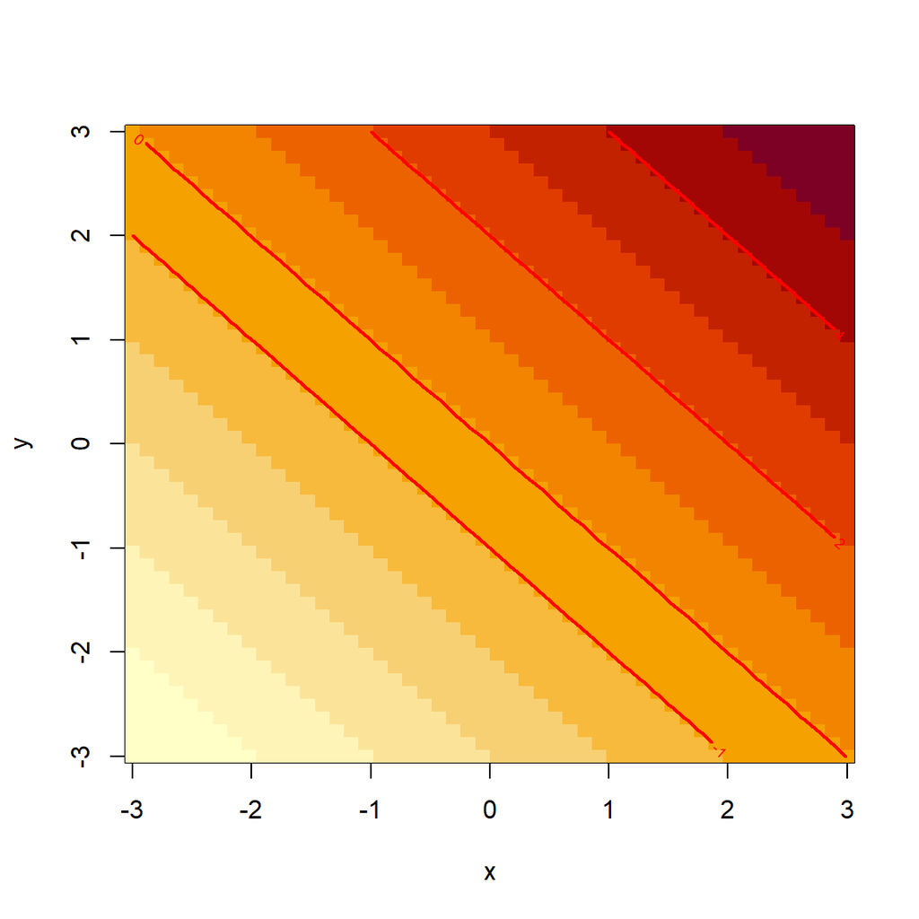

```r
image(x,y,z)
contour(x, y, z, levels = c(-1, 0, 2, 4), add = TRUE, col = "red", lwd = 2)
```

2.- z= 6-2x-3y, c= 0,2,4,6,8,10

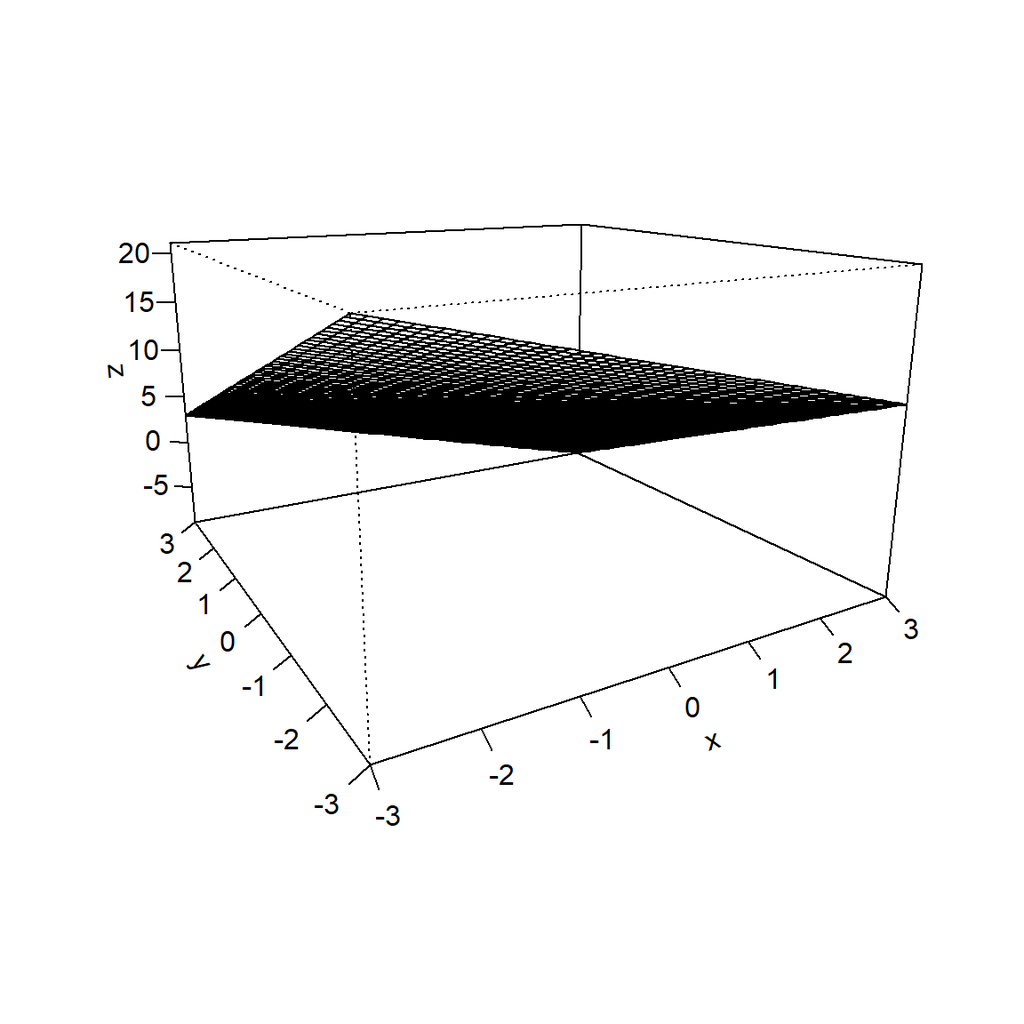

```r
x <- seq(-3,3,length=50)
y <- seq(-3,3, length=50)
z <- outer(x, y, function(x, y) 6 - 2*x - 3*y)
persp(x,y,z, theta=-30, expand=0.6, ticktype = "detailed")
```

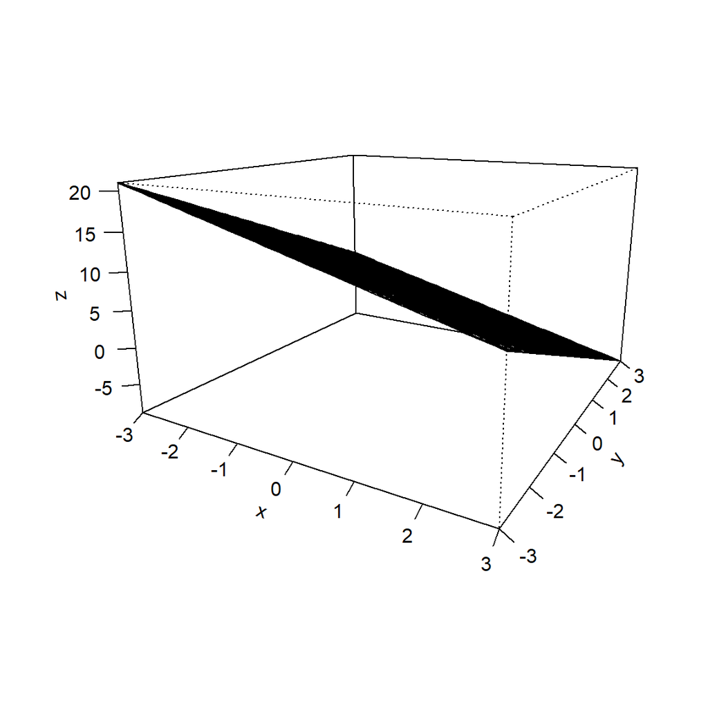

```r
persp(x,y,z, theta=30, expand=0.6, ticktype = "detailed")
```

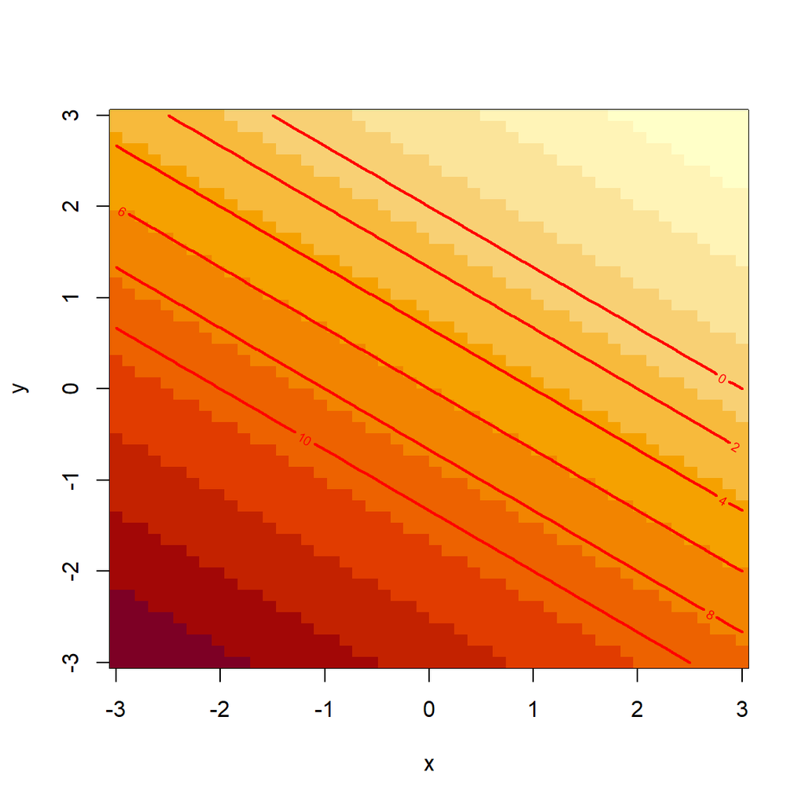

```r
image(x,y,z)
contour(x, y, z, levels = c(0, 2, 4, 6, 8, 10), add = TRUE, col = "red", lwd = 2)
```

3.- z= (x<sup>2)+4(y</sup>2), c= 0,1,2,3,4

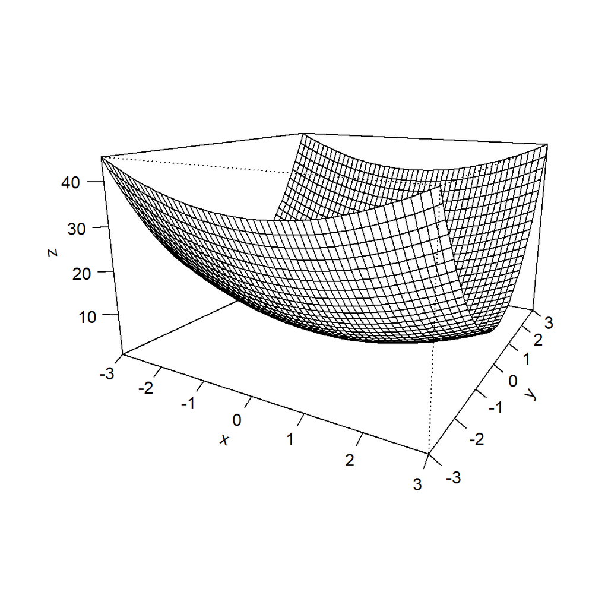

```r
x <- seq(-3,3,length=50)
y <- seq(-3,3, length=50)
z <- outer(x, y, function(x, y) x^2 + 4*y^2)
persp(x,y,z, theta=30, expand=0.6, ticktype = "detailed")
persp(x,y,z, theta=30, expand=0.6, ticktype = "detailed")
```

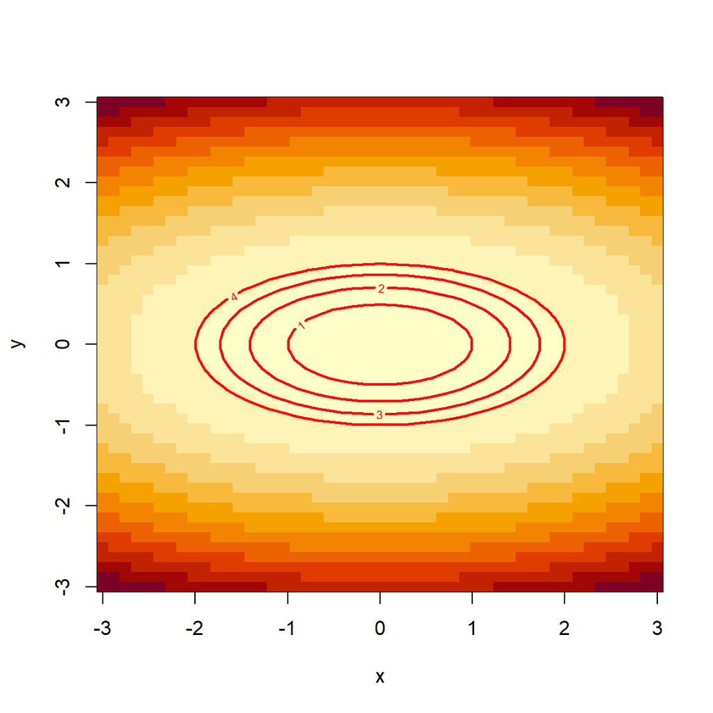

```r
image(x,y,z)
contour(x, y, z, levels = c(0, 1, 2, 3, 4), add = TRUE, col = "red", lwd = 2)
```

4.- f(x,y)= sqrt(9-(x<sup>2)-(y</sup>2)), c= 0,1,2,3

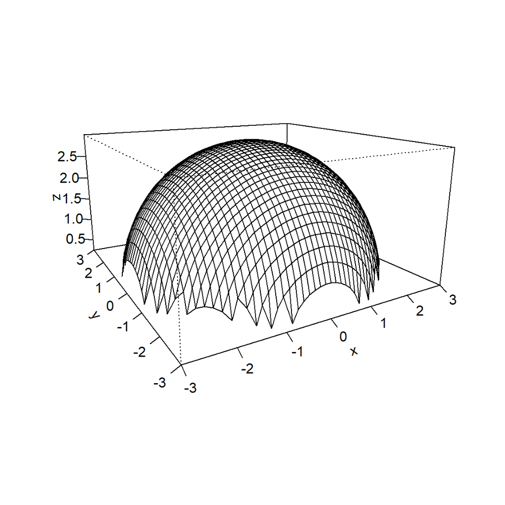

```r
x <- seq(-3,3,length=50)
y <- seq(-3,3, length=50)
z <- outer(x, y, function(x, y) sqrt(9 - x^2 - y^2))
persp(x,y,z, theta=-30, expand=0.5, ticktype = "detailed")
```

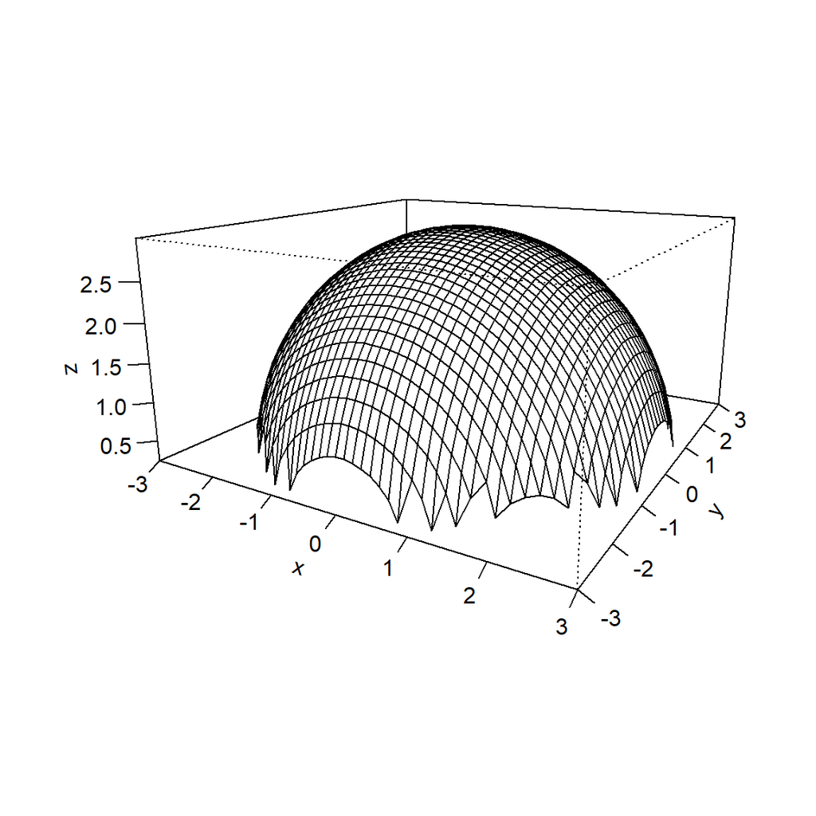

```r
persp(x,y,z, theta=30,expand=0.5,ticktype = "detailed")
```

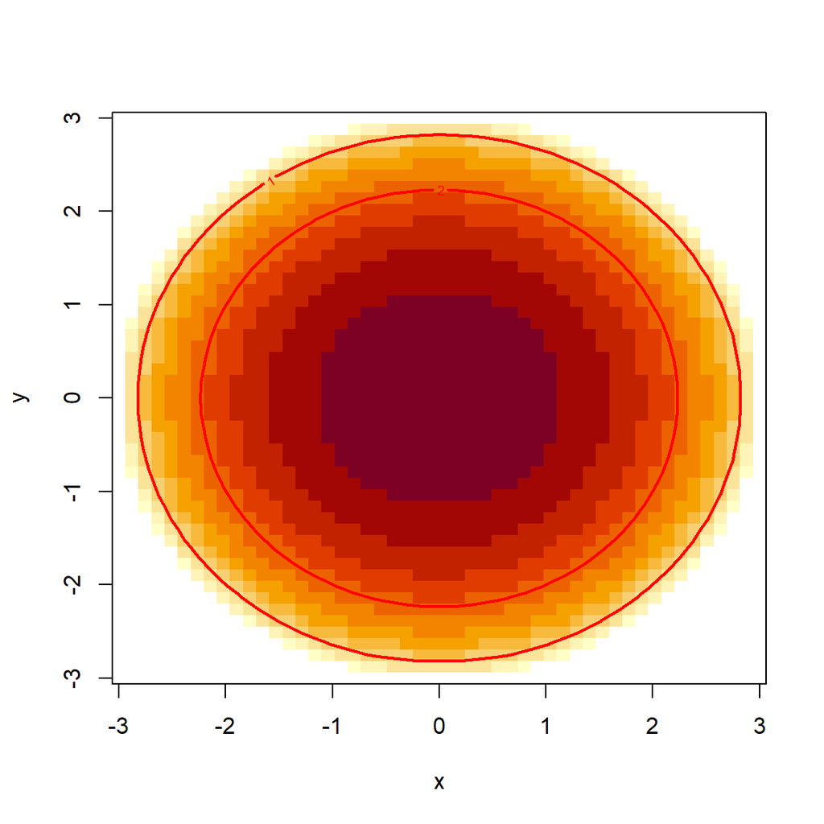

```r
image(x,y,z)
contour(x, y, z, levels = c(0, 1, 2, 3), add = TRUE, col = "red", lwd = 2)
```

5.- f(x,y)= xy, c= ±1, ±2, ±3, ±4, ±5, ±6

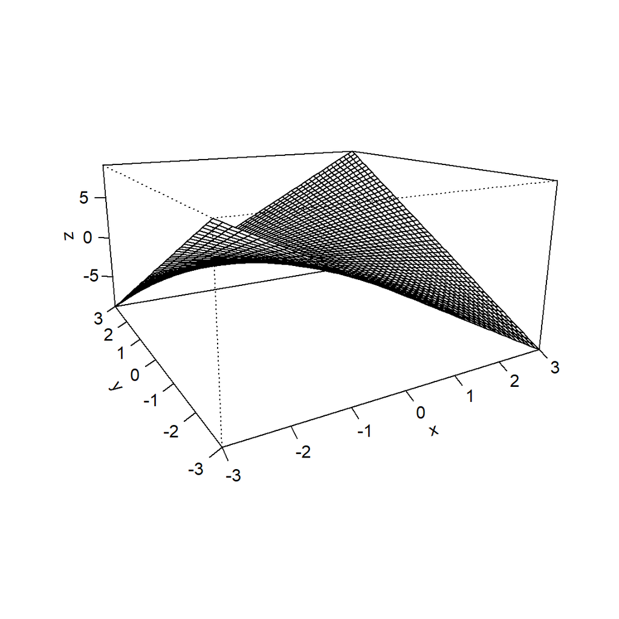

```r
x <- seq(-3,3,length=50)
y <- seq(-3,3, length=50)
z <- outer(x, y, function(x, y) x * y)
persp(x,y,z, theta=-30, expand=0.5, ticktype = "detailed")
```

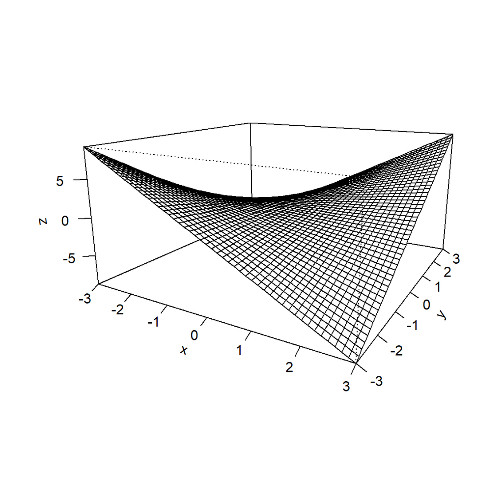

```r
persp(x,y,z, theta=30,expand=0.5,ticktype = "detailed")
```

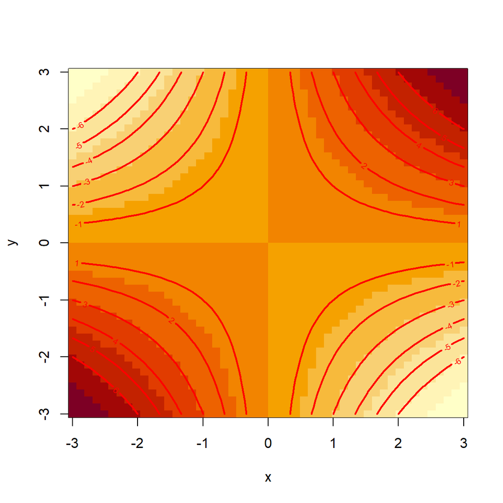

```r
image(x,y,z)
contour(x, y, z, levels = c(-6, -5, -4, -3, -2, -1, 1, 2, 3, 4, 5, 6), add = TRUE, col = "red", lwd = 2)
```

6.- f(x,y)= e^((xy)/2), c= 2,3,4,1/2,1/2,1/4

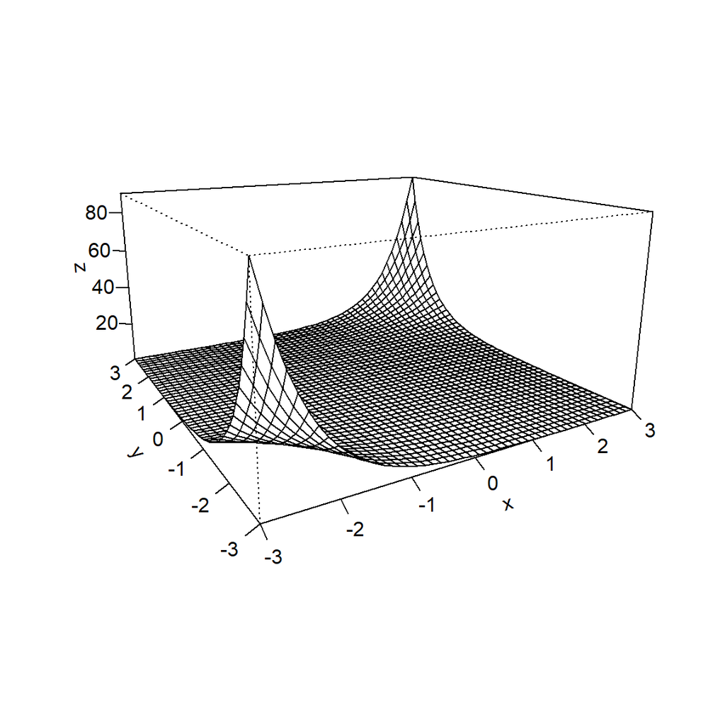

```r
x <- seq(-3,3,length=50)
y <- seq(-3,3, length=50)
z <- outer(x, y, function(x, y) exp((x * y)/2))
persp(x,y,z, theta=-30, expand=0.5, ticktype = "detailed")
```

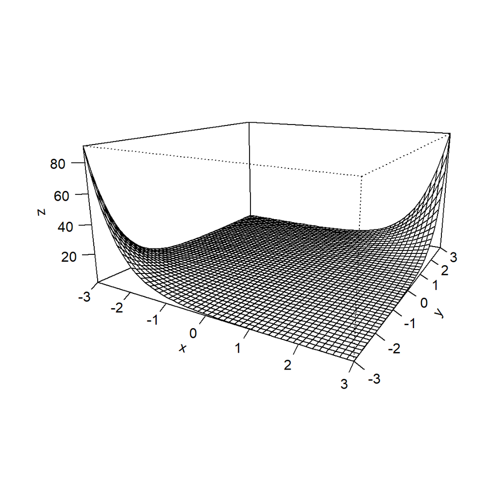

```r
persp(x,y,z, theta=30,expand=0.5,ticktype = "detailed")
```